# Homework 01

## Question 1 (Least squares and matrix calculations)

### (a)

$\mathbf X$ has dimensions $100 \times 6$ (100 observations, 6 columns including the intercept) and rank 6. With probability one, a Gaussian design of this size has full column rank.

The least-squares estimate is computed via `np.linalg.lstsq`, which uses the SVD internally. Forming $(\mathbf X^{\mathsf T}\mathbf X)^{-1}$ explicitly is unnecessary and can amplify numerical error.

```python
import numpy as np

rng = np.random.default_rng(43201)

n = 100
p = 5

x = rng.normal(size=(n, p))
X = np.column_stack([np.ones(n), x])
beta = np.array([3.0, 1.4, -0.9, 0.7, 0.0, 1.1])

epsilon = rng.normal(loc=0.0, scale=0.7, size=n)
y = X @ beta + epsilon

beta_hat, _, rank, _ = np.linalg.lstsq(X, y, rcond=None)
fitted_values = X @ beta_hat
residuals = y - fitted_values

print("Dimensions:", X.shape)
print("Rank:", rank)
print("\nTruth and estimate:")
print(np.column_stack([beta, beta_hat]).round(4))
```

```
Dimensions: (100, 6)
Rank: 6

Truth and estimate:
[[ 3.      2.9731]
 [ 1.4     1.324 ]
 [-0.9    -0.8415]
 [ 0.7     0.7204]
 [ 0.     -0.0831]
 [ 1.1     1.1651]]
```

The estimates are reasonably close to the generating values. They do not match exactly because this is one realization of the noise $\boldsymbol\varepsilon$. In particular, the estimated coefficient of $x_4$ is near its true value of zero.

### (b)

```python
training_rmse = np.sqrt(np.mean(residuals**2))
print("Training RMSE:", round(training_rmse, 4))
```

```
Training RMSE: 0.6463
```

### (c)

```python
normal_equation_error = np.max(np.abs(X.T @ residuals))
print("||X^T r||_inf:", normal_equation_error)
```

```
||X^T r||_inf: 1.474152243630658e-12
```

This value is near zero (on the order of $10^{-12}$) because the least-squares solution satisfies the normal equations $\mathbf X^{\mathsf T}(\mathbf y - \mathbf X\widehat{\boldsymbol\beta}) = \mathbf 0$. Geometrically, the residual vector $\mathbf r$ is orthogonal to every column of $\mathbf X$, including the intercept column. The latter also implies that the residuals sum to approximately zero. The tiny nonzero value is floating-point rounding error.

## Question 2 (Gaussian likelihood for linear regression)

### (a)

For fixed $\sigma^2$, the first term in the log-likelihood does not depend on $\boldsymbol\beta$, and the multiplier of the residual sum of squares is $-1/(2\sigma^2) < 0$. Therefore,

$$\underset{\boldsymbol\beta}{\operatorname{argmax}}\,\ell(\boldsymbol\beta,\sigma^2)
=
\underset{\boldsymbol\beta}{\operatorname{argmin}}\,\lVert\mathbf y - \mathbf X\boldsymbol\beta\rVert_2^2.$$

The maximum-likelihood estimate of $\boldsymbol\beta$ is the least-squares estimate from Question 1.

### (b)

Writing $v = \sigma^2$ and holding $\boldsymbol\beta$ fixed:

$$\frac{\partial\ell}{\partial v}
= -\frac{n}{2v} + \frac{\text{RSS}}{2v^2}.$$

Setting to zero gives

$$\widehat{\sigma}_{\text{MLE}}^2 = \frac{\text{RSS}}{n}.$$

The second derivative is $-n/(2\widehat{v}^2) < 0$, confirming a maximum. The unbiased estimator divides by $n - 6$ instead of $n$ because fitting 6 regression coefficients consumes 6 degrees of freedom. Under the Gaussian linear model, $\mathbb{E}(\text{RSS}) = (n-6)\sigma^2$, so dividing by $n - 6$ corrects the bias.

```python
rss = residuals @ residuals
sigma2_mle = rss / n
sigma2_unbiased = rss / (n - X.shape[1])

print("MLE variance:", round(sigma2_mle, 4))
print("Unbiased variance:", round(sigma2_unbiased, 4))
```

```
MLE variance: 0.4178
Unbiased variance: 0.4444
```

### (c)

At $t = 0$ the coefficient vector equals $\widehat{\boldsymbol\beta}$. Moving away from zero changes only the coefficient of $x_2$, increases the residual sum of squares, and decreases the log-likelihood. The maximum therefore occurs at $t = 0$, confirming that the MLE of $\boldsymbol\beta$ is the least-squares estimate.

```
Maximizing t: 0.0
```

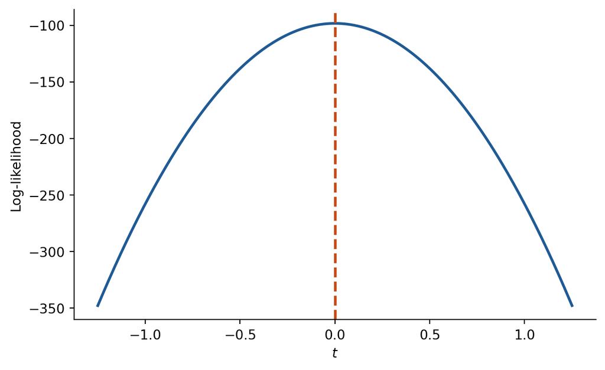

```python
import matplotlib.pyplot as plt

def log_likelihood(beta_value, sigma2, X, y):
    residual = y - X @ beta_value
    return (
        -X.shape[0] / 2 * np.log(2 * np.pi * sigma2)
        - residual @ residual / (2 * sigma2)
    )

e_x2 = np.array([0.0, 0.0, 1.0, 0.0, 0.0, 0.0])
t_grid = np.linspace(-1.25, 1.25, 251)
profile_log_likelihood = np.array(
    [
        log_likelihood(beta_hat + t * e_x2, sigma2_mle, X, y)
        for t in t_grid
    ]
)

print("Maximizing t:", t_grid[np.argmax(profile_log_likelihood)])

fig, ax = plt.subplots(figsize=(7, 4.2))
ax.plot(t_grid, profile_log_likelihood, color="#1F5A94", linewidth=2)
ax.axvline(0, color="#C84A16", linestyle="--", linewidth=2)
ax.set(xlabel=r"$t$", ylabel="Log-likelihood")
ax.spines[["top", "right"]].set_visible(False)
plt.show()
```

## Question 3 (Starting values in nonconvex optimization)

### (a)

The plot shows a nonconvex objective with two local minima separated by a local maximum near $x \approx -7$. For large positive $x$, $\exp(1.5x)$ dominates and $f \to +\infty$. For large negative $x$, $-0.05x^3$ is positive and grows, but $-3(x+6)^2$ creates a deep trough around $x \approx -33$. A gradient-based optimizer uses only local information, so its result depends on the starting point and which basin of attraction contains it.

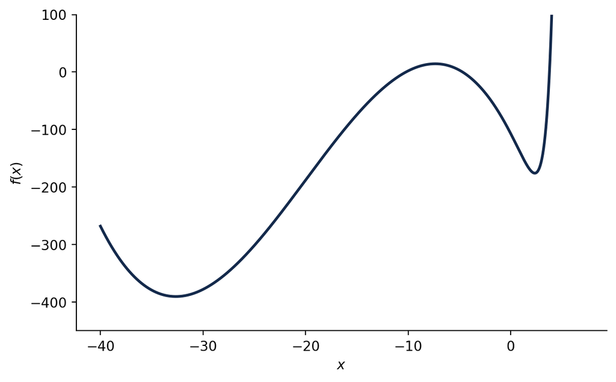

```python
from scipy.optimize import minimize

def objective(x_val):
    return np.exp(1.5 * x_val) - 3 * (x_val + 6) ** 2 - 0.05 * x_val ** 3

def gradient(x_val):
    return 1.5 * np.exp(1.5 * x_val) - 6 * (x_val + 6) - 0.15 * x_val ** 2

x_grid = np.linspace(-40, 7, 1200)

fig, ax = plt.subplots(figsize=(7, 4.2))
ax.plot(x_grid, objective(x_grid), color="#13294B", linewidth=2)
ax.set(ylim=(-450, 100), xlabel=r"$x$", ylabel=r"$f(x)$")
ax.spines[["top", "right"]].set_visible(False)
plt.show()
```

### (b)

```python
starts = [-15.0, 0.0]
optimization_results = []
for start in starts:
    result = minimize(
        fun=lambda value: objective(value[0]),
        x0=np.array([start]),
        jac=lambda value: np.array([gradient(value[0])]),
        method="BFGS",
    )
    optimization_results.append(result)
    print(
        f"start={start:5.1f}, "
        f"x={result.x[0]: .6f}, "
        f"f(x)={result.fun: .6f}, "
        f"|f'(x)|={abs(gradient(result.x[0])):.3e}, "
        f"converged={result.success}"
    )
```

```
start=-15.0, x=-32.649111, f(x)=-390.385770, |f'(x)|=2.842e-14, converged=True
start=  0.0, x= 2.349967, f(x)=-175.862620, |f'(x)|=8.127e-06, converged=True
```

Both runs report convergence with gradients near zero, confirming each found a stationary local minimum.

### (c)

The two runs converge to different local minima because BFGS is a local optimizer — it follows the gradient downhill from its starting point into the nearest basin. Starting at $x^{(0)} = -15$ reaches the basin around $x \approx -32.6$; starting at $x^{(0)} = 0$ reaches the basin around $x \approx 2.35$.

The run from $x^{(0)} = -15$ gives the **lower objective value** ($-390.39$ vs $-175.86$). Before claiming this is the global minimum, we would need additional evidence: a search for all roots of $f'(x)$ and comparison of $f$ at every stationary point, analysis of limiting behavior as $x \to \pm\infty$, or a global optimization method. A dense plot or many starting values provide useful numerical evidence but do not prove global optimality by themselves.

## Question 4 (Nearly collinear predictors)

### (a)

```python
rng_q4 = np.random.default_rng(43202)
u = rng_q4.normal(size=n)

x6 = x[:, 0] + 1e-4 * u
X_plus = np.column_stack([X, x6])
y_star = y + 1e-3 * u

beta_original = np.linalg.lstsq(X, y, rcond=None)[0]
beta_augmented = np.linalg.lstsq(X_plus, y, rcond=None)[0]

fitted_original = X @ beta_original
fitted_augmented = X_plus @ beta_augmented

condition_X = np.linalg.cond(X)
condition_X_plus = np.linalg.cond(X_plus)
rmse_X = np.sqrt(np.mean((y - fitted_original) ** 2))
rmse_X_plus = np.sqrt(np.mean((y - fitted_augmented) ** 2))

print("X  condition number:", round(condition_X, 2), " RMSE:", round(rmse_X, 4))
print("X+ condition number:", round(condition_X_plus, 2), " RMSE:", round(rmse_X_plus, 4))
print("\nAugmented fit coefficients (x1 and x6):")
print("  beta_x1:", round(beta_augmented[1], 3))
print("  beta_x6:", round(beta_augmented[6], 3))
print("  sum:    ", round(beta_augmented[1] + beta_augmented[6], 3))
```

```
X  condition number: 1.45  RMSE: 0.6463
X+ condition number: 20339.84  RMSE: 0.634

Augmented fit coefficients (x1 and x6):
  beta_x1: -1329.743
  beta_x6: 1331.06
  sum:     1.317
```

The condition number increases by a factor of roughly 14,000 because $\mathbf x_6 \approx \mathbf x_1$ makes $\mathbf X_+$ nearly rank-deficient. The training RMSE barely changes because the extra column provides almost no new information. The individual coefficients of $\mathbf x_1$ and $\mathbf x_6$ are enormous with opposite signs, but their sum remains near the coefficient of $x_1$ from the original fit.

### (b)

```python
beta_perturbed = np.linalg.lstsq(X_plus, y_star, rcond=None)[0]

fitted_perturbed = X_plus @ beta_perturbed
fitted_difference = fitted_perturbed - fitted_augmented

print("Coefficients for y:  x1 =", round(beta_augmented[1], 3),
      " x6 =", round(beta_augmented[6], 3))
print("Coefficients for y*: x1 =", round(beta_perturbed[1], 3),
      " x6 =", round(beta_perturbed[6], 3))
print("Changes:             x1 =", round(beta_perturbed[1] - beta_augmented[1], 3),
      " x6 =", round(beta_perturbed[6] - beta_augmented[6], 3))
print("\nFitted-value RMSD:", round(np.sqrt(np.mean(fitted_difference**2)), 6))
print("Fitted-value max |diff|:", round(np.max(np.abs(fitted_difference)), 6))
```

```
Coefficients for y:  x1 = -1329.743  x6 = 1331.06
Coefficients for y*: x1 = -1339.743  x6 = 1341.06
Changes:             x1 = -10.0  x6 = 10.0

Fitted-value RMSD: 0.000975
Fitted-value max |diff|: 0.002351
```

The coefficients of $x_1$ and $x_6$ change by $\pm 10$, yet the fitted values barely move.

### (c)

The response perturbation satisfies

$$\mathbf y^\star - \mathbf y
= 10^{-3}\mathbf u
= 10 \cdot 10^{-4}\mathbf u
= 10(\mathbf x_6 - \mathbf x_1).$$

The augmented fit can reproduce this change by setting $\Delta\widehat\beta_1 = -10$ and $\Delta\widehat\beta_6 = +10$, with all other coefficient changes essentially zero. The corresponding fitted-value change is only $10^{-3}\mathbf u$, whose entries are on the order of one-thousandth.

Predictions depend on $\widehat\beta_1 x_1 + \widehat\beta_6 x_6 \approx (\widehat\beta_1 + \widehat\beta_6) x_1$ since $x_6 \approx x_1$. Only the sum $\widehat\beta_1 + \widehat\beta_6$ matters for prediction; the individual split is undetermined by the data. When predictors are nearly collinear, individual coefficient estimates are highly unstable and uninterpretable even though predictions remain stable. The data identify the combined contribution much more clearly than separate effects.

## Question 5 (Data preparation and summary statistics)

### (a)

```python
import os
from pathlib import Path
import pandas as pd

data_file = Path("data") / "data-manipulation.csv"
if not data_file.exists():
    document_dir = Path(os.environ.get("QUARTO_DOCUMENT_PATH", "."))
    data_file = document_dir / "data" / "data-manipulation.csv"
small_data = pd.read_csv(data_file)

print("Dimensions:", small_data.shape)
print("\nColumn types:")
print(small_data.dtypes)
print("\nDuplicated identifiers:", small_data["observation_id"].duplicated().sum())
print("\nMissing values per column:")
print(small_data.isna().sum())

analysis_data = small_data.dropna(subset=["response"]).copy()
analysis_data["feature_sum"] = analysis_data["x1"] + analysis_data["x2"]
print("\nAnalysis table dimensions:", analysis_data.shape)
```

```
Dimensions: (24, 5)

Column types:
observation_id     object
group              object
x1                float64
x2                float64
response          float64
dtype: object

Duplicated identifiers: 0

Missing values per column:
observation_id    0
group             0
x1                0
x2                0
response          3
dtype: int64

Analysis table dimensions: (21, 6)
```

The original table has 24 rows and 5 columns. The identifiers are unique. Only `response` contains missing values, with 3 missing entries. Removing those rows leaves 21 observations for response-based analyses.

### (b)

These summaries describe **only observations with recorded (non-missing) responses**. They should not be described as summaries of all 24 rows.

```python
group_summary = (
    analysis_data.groupby("group", as_index=False)
    .agg(
        observations=("response", "size"),
        mean_response=("response", "mean"),
        mean_feature_sum=("feature_sum", "mean"),
    )
)
print(group_summary.to_string(index=False))
```

```
group  observations  mean_response  mean_feature_sum
    A             7       5.600000          3.600000
    B             7       7.602857          4.928571
    C             7       7.997143          6.585714
```

### (c)

```python
largest_three = (
    analysis_data.sort_values("response", ascending=False)
    .loc[:, ["observation_id", "group", "response", "feature_sum"]]
    .head(3)
)
print(largest_three.to_string(index=False))

number_recorded = small_data["response"].notna().sum()
assert len(analysis_data) == number_recorded
assert not analysis_data["response"].isna().any()
assert analysis_data["observation_id"].is_unique
print("\nAll checks passed.")
```

```
observation_id group  response  feature_sum
        obs-22     C      9.24          6.6
        obs-16     B      9.00          5.2
        obs-14     B      8.66          5.0

All checks passed.
```

## Question 6 (Can 39 million Fitbit records represent US adults?)

### (a)

The 39 million daily records are **not** independent observations. They are repeated measurements from approximately 59,000 participants. Days from the same participant are correlated because health, occupation, habits, and environment persist over time.

Participants contribute different numbers of recorded days. Longer enrollment, consistent device use, regular synchronization, technical access, and fewer missing or invalid days can all increase the number of records contributed. Illness, travel, irregular work schedules, privacy concerns, device failure, or inconsistent use can reduce it.

Averaging all recorded days gives more weight to participants with more recorded days. If the number of recorded days is related to activity level, this record-weighted average can differ systematically from an average that gives each participant equal weight.

### (b)

No. This comparison does not show that already owning a Fitbit causes people to walk more. The BYOD and WEAR groups were not formed by random assignment — they differ by self-selection. The reported demographic differences (77.3% vs 55.1% White; 6.1% vs 15.2% low-income) confirm that the two groups contain different participant populations.

A plausible alternative explanation: people who are already physically active are more likely to purchase a fitness tracker to monitor their activity. The 1,070-step difference could reflect pre-existing differences between the kinds of people who self-select into each group (confounding), not a causal effect of device ownership.

### (c)

A US adult must pass through several selection stages before contributing an observed step count:

1. **Enrollment in All of Us.** Participation is voluntary. Enrollees may differ from other US adults in health, access to health care, interest in research, or willingness to share data.
2. **Entry through BYOD or WEAR.** A BYOD participant must already own a compatible Fitbit. A WEAR participant must be invited and agree to receive and use a device.
3. **Consent and technical connection.** A participant must agree to share wearable data and successfully connect an account.
4. **Continued device use and valid records.** The participant must continue to wear and synchronize the device, and each recorded day must satisfy the study’s validity requirements.

Selection at any of these stages can affect the estimated population mean when inclusion is related to activity. A large number of records reduces random variation around the mean for the observed participant-days, but it does not remove a systematic difference between those observations and the target population.

The naive average of all recorded daily step counts has two problems for the stated target. First, it gives more weight to participants with more recorded days. Second, the observed participants may not represent US adults, even after each participant is given equal weight. An analysis aimed at the stated target should first summarize activity within each participant, account for dependence among repeated days, and then consider population weighting or calibration. These adjustments require assumptions and cannot automatically remove selection caused by unmeasured factors.